# Identifying Environmentally Responsible US Public Transit Systems

## Data Acquisition

The research utilizes Energy Information Administration (EIA) electricity profiles, National Transit Database (NTD) energy consumption, and Service by Agency records.

**View datasets previews**

#### EIA State Electricity Profiles

| CO2_MWh | primary_source | electricity_price_MWh | generation_MWh | state | abbreviation |
| --- | --- | --- | --- | --- | --- |
| 747 | Natural gas | 119.0 | 142,921,216 | Alabama | AL |
| 1,196 | Natural gas | 221.7 | 6,690,506 | Alaska | AK |
| 634 | Natural gas | 127.4 | 116,026,511 | Arizona | AZ |
| 960 | Natural gas | 95.9 | 61,542,484 | Arkansas | AR |
| 407 | Natural gas | 270.4 | 214,191,383 | California | CA |
| 958 | Natural gas | 120.7 | 58,798,395 | Colorado | CO |
| 541 | Natural gas | 243.7 | 44,761,412 | Connecticut | CT |
| 1,126 | Natural gas | 135.6 | 4,799,212 | Delaware | DE |
| 765 | Natural gas | 125.3 | 266,119,236 | Florida | FL |
| 672 | Natural gas | 114.0 | 139,805,428 | Georgia | GA |

#### NTD Energy Consumption

| NTD ID | Mode | Agency Name | Gallons of Bio-Diesel | Bio-Diesel Description | Gallons of Bunker Fuel | Gallons of Compressed Natural Gas | Gallons of Diesel Fuel | Kilowatt hours of Electric Battery | Kilowatt hours of Electric Propulsion | Gallons of Ethanol | Gallons of Gasoline | Kilograms of Hydrogen | Gallons of Kerosene | Gallons of Liquified Nat Gas | Gallons of Liquified Petroleum Gas |
| --- | --- | --- | --- | --- | --- | --- | --- | --- | --- | --- | --- | --- | --- | --- | --- |
| 1 | DR | King County | 0 | 0 | 0 | 0 | 0 | 0 | 0 | 0 | 1,030,289 | 0 | 0 | 0 | 399,385 |
| 1 | FB | King County | 0 | 0 | 0 | 0 | 288,130 | 0 | 0 | 0 | 0 | 0 | 0 | 0 | 0 |
| 1 | MB | King County | 139,825 | 0 | 0 | 0 | 9,072,034 | 2,203,762 | 0 | 0 | 196,299 | 0 | 0 | 0 | 0 |
| 1 | SR | King County | 0 | 0 | 0 | 0 | 0 | 0 | 2,103,938 | 0 | 0 | 0 | 0 | 0 | 0 |
| 1 | TB | King County | 0 | 0 | 0 | 0 | 0 | 0 | 11,463,511 | 0 | 0 | 0 | 0 | 0 | 0 |
| 1 | VP | King County | 0 | 0 | 0 | 0 | 0 | 20,111 | 0 | 0 | 467,833 | 0 | 0 | 0 | 0 |
| 2 | DR | Spokane Transit Authority | 0 | 0 | 0 | 0 | 33,515 | 0 | 0 | 0 | 308,025 | 0 | 0 | 0 | 0 |
| 2 | MB | Spokane Transit Authority | 0 | 0 | 0 | 0 | 1,176,229 | 3,698,971 | 0 | 0 | 0 | 0 | 0 | 0 | 0 |
| 2 | VP | Spokane Transit Authority | 0 | 0 | 0 | 0 | 0 | 0 | 0 | 0 | 58,559 | 0 | 0 | 0 | 0 |
| 3 | DR | Pierce County Transportation Benefit Area Authority | 0 | 0 | 0 | 14,207 | 0 | 0 | 0 | 0 | 357,634 | 0 | 0 | 0 | 0 |

#### NTD Service by Agency

| NTD_ID | AGENCY | reporter_type | organization_type | city | state | mode | type_of_service | uza_code | uza_name | uza_sq_miles | uza_population | service_area_sq_miles | service_area_population | flagged_likely_inaccurate | total_upt | sum_passenger_miles |
| --- | --- | --- | --- | --- | --- | --- | --- | --- | --- | --- | --- | --- | --- | --- | --- | --- |
| 00001 | King County, dba: King County Metro | Full Reporter | City, County or Local Government Unit or Department of Transportation | Seattle | WA | DR | PT | 80389 | Seattle–Tacoma, WA | 982.52 | 3,544,011 | 2,134 | 2,411,700 | FALSE | 1,129,315 | 7,951,559 |
| 00001 | King County, dba: King County Metro | Full Reporter | City, County or Local Government Unit or Department of Transportation | Seattle | WA | DR | TX | 80389 | Seattle–Tacoma, WA | 982.52 | 3,544,011 | 2,134 | 2,411,700 | FALSE | 148,182 | 1,881,154 |
| 00001 | King County, dba: King County Metro | Full Reporter | City, County or Local Government Unit or Department of Transportation | Seattle | WA | FB | DO | 80389 | Seattle–Tacoma, WA | 982.52 | 3,544,011 | 2,134 | 2,411,700 | FALSE | 547,531 | 2,339,926 |
| 00001 | King County, dba: King County Metro | Full Reporter | City, County or Local Government Unit or Department of Transportation | Seattle | WA | MB | DO | 80389 | Seattle–Tacoma, WA | 982.52 | 3,544,011 | 2,134 | 2,411,700 | FALSE | 77,866,225 | 261,633,653 |
| 00001 | King County, dba: King County Metro | Full Reporter | City, County or Local Government Unit or Department of Transportation | Seattle | WA | MB | PT | 80389 | Seattle–Tacoma, WA | 982.52 | 3,544,011 | 2,134 | 2,411,700 | FALSE | 1,002,310 | 4,038,336 |
| 00001 | King County, dba: King County Metro | Full Reporter | City, County or Local Government Unit or Department of Transportation | Seattle | WA | SR | DO | 80389 | Seattle–Tacoma, WA | 982.52 | 3,544,011 | 2,134 | 2,411,700 | FALSE | 1,624,485 | 1,717,764 |
| 00001 | King County, dba: King County Metro | Full Reporter | City, County or Local Government Unit or Department of Transportation | Seattle | WA | TB | DO | 80389 | Seattle–Tacoma, WA | 982.52 | 3,544,011 | 2,134 | 2,411,700 | FALSE | 10,533,214 | 17,694,656 |
| 00001 | King County, dba: King County Metro | Full Reporter | City, County or Local Government Unit or Department of Transportation | Seattle | WA | VP | DO | 80389 | Seattle–Tacoma, WA | 982.52 | 3,544,011 | 2,134 | 2,411,700 | FALSE | 1,580,828 | 33,473,573 |
| 00002 | Spokane Transit Authority | Full Reporter | Independent Public Agency or Authority of Transit Service | Spokane | WA | DR | DO | 83764 | Spokane, WA | 171.67 | 447,279 | 248 | 481,616 | FALSE | 219,891 | 1,810,140 |
| 00002 | Spokane Transit Authority | Full Reporter | Independent Public Agency or Authority of Transit Service | Spokane | WA | DR | PT | 83764 | Spokane, WA | 171.67 | 447,279 | 248 | 481,616 | FALSE | 182,285 | 1,534,920 |

## Data Cleaning and Preparation

The baseline data-quality checks involving `glimpse()` and `skimr::skim()` were performed on all three datasets to understand variable types, missing values, and summary statistics.

The datasets originally used two-letter transportation codes. They were converted into descriptive names.

**Conversion results**

| Original code | Recoded transportation mode |
| --- | --- |
| TR | Aerial Tramway |
| AR | Alaska Railroad |
| MB | Bus |
| RB | Bus Rapid Transit |
| CC | Cable Car |
| CB | Commuter Bus |
| CR | Commuter Rail |
| DR | Demand Response |
| FB | Ferryboat |
| HR | Heavy Rail |
| YR | Hybrid Rail |
| IP | Inclined Plane |
| LR | Light Rail |
| MG | Monorail/Automated Guideway |
| SR | Streetcar Rail |
| TB | Trolleybus |
| VP | Vanpool |

| Dataset | Distinct modes | Unknown modes |
| --- | --- | --- |
| NTD_ENERGY | 17 | 0 |
| NTD_SERVICE | 17 | 0 |

## Data Integration and Initial Exploration

### EIA State Electricity Profiles

#### Five States with the Most Expensive Retail Electricity

**Electricity price code**

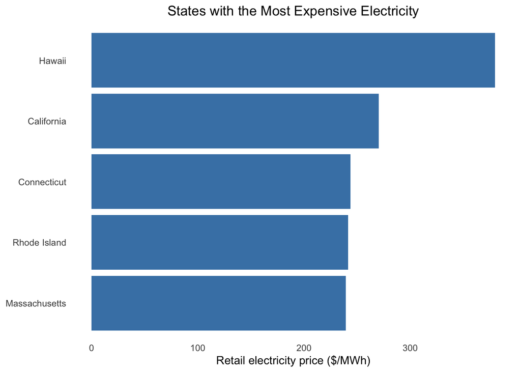

```r
EIA_SEP_REPORT |>
  slice_max(electricity_price_MWh, n = 5, with_ties = FALSE) |>
  ggplot(aes(
    x = reorder(state, electricity_price_MWh),
    y = electricity_price_MWh
  )) +
  geom_col(fill = "steelblue") +
  coord_flip() +
  labs(
    title = "States with the Most Expensive Electricity",
    x = NULL,
    y = "Retail electricity price ($/MWh)"
  ) +
  theme_minimal() +
  theme(
    plot.title = element_text(hjust = 0.5),
    panel.grid = element_blank()
  )
```

#### Five States with the Dirtiest Electricity Mix

The states are ranked by carbon dioxide (CO₂) emissions per megawatt-hour.

**CO₂ emissions table**

```r
EIA_SEP_REPORT |>
  slice_max(CO2_MWh, n = 5, with_ties = FALSE) |>
  arrange(desc(CO2_MWh)) |>
  select(
    State = state,
    `CO2 Emissions (lbs/MWh)` = CO2_MWh
  ) |>
  knitr::kable(
    format.args = list(big.mark = ",")
  )
```

| State | CO2 Emissions (lbs/MWh) |
| --- | --- |
| West Virginia | 1,912 |
| Kentucky | 1,744 |
| Wyoming | 1,724 |
| Missouri | 1,456 |
| Hawaii | 1,426 |

#### How Much Cleaner Is New York’s Electricity Mix Than Texas’s?

New York’s electricity mix is approximately 1.53 times cleaner than Texas’s, based on CO₂ emissions per megawatt-hour.

### EDA - NTD Energy Usage

#### Five Transit Agencies with the Highest Fuel Consumption

**Top five transit agencies with the highest fuel consumption code**

```r
fuel_cols <- names(NTD_ENERGY)[
  str_detect(names(NTD_ENERGY), regex("gallons", ignore_case = TRUE))
]

agency_fuel <- NTD_ENERGY |>
  group_by(`NTD ID`, `Agency Name`) |>
  summarise(
    across(all_of(fuel_cols), ~sum(.x, na.rm = TRUE)),
    .groups = "drop"
  ) |>
  mutate(
    Total_Gallons = rowSums(
      pick(all_of(fuel_cols)),
      na.rm = TRUE
    )
  )

top_five_agencies <- agency_fuel |>
  slice_max(Total_Gallons, n = 5, with_ties = FALSE) |>
  filter(Total_Gallons > 0) |>
  arrange(desc(Total_Gallons))

top_five_agencies |>
  select(`Agency Name`, all_of(fuel_cols), Total_Gallons) |>
  rename(`Total Gallons` = Total_Gallons) |>
  knitr::kable(
    format.args = list(big.mark = ","),
    digits = 0
  )
```

| Agency Name | Gallons of Bio-Diesel | Gallons of Bunker Fuel | Gallons of Compressed Natural Gas | Gallons of Diesel Fuel | Gallons of Ethanol | Gallons of Gasoline | Gallons of Kerosene | Gallons of Liquified Nat Gas | Gallons of Liquified Petroleum Gas | Total Gallons |
| --- | --- | --- | --- | --- | --- | --- | --- | --- | --- | --- |
| New Jersey Transit Corporation | 0 | 0 | 1,521,492 | 38,144,027 | 0 | 2,055,895 | 0 | 0 | 0 | 41,721,414 |
| MTA New York City Transit | 0 | 0 | 6,328,381 | 30,217,934 | 0 | 4,270,146 | 0 | 0 | 0 | 40,816,461 |
| Los Angeles County Metropolitan Transportation Authority | 0 | 0 | 30,410,141 | 0 | 0 | 994,810 | 0 | 0 | 0 | 31,404,951 |
| Northeast Illinois Regional Commuter Railroad Corporation | 0 | 0 | 0 | 26,829,691 | 0 | 0 | 0 | 0 | 0 | 26,829,691 |
| Massachusetts Bay Transportation Authority | 0 | 0 | 1,534,123 | 20,627,960 | 0 | 1,290,452 | 0 | 0 | 0 | 23,452,535 |

#### Fuel Consumption Across US Public Transit

Electricity and hydrogen are excluded from the chart because they are measured in different units (kilowatt-hours and kilograms, respectively). Additionally, fuels with zero consumption are excluded as well.

**Fuel consumption code**

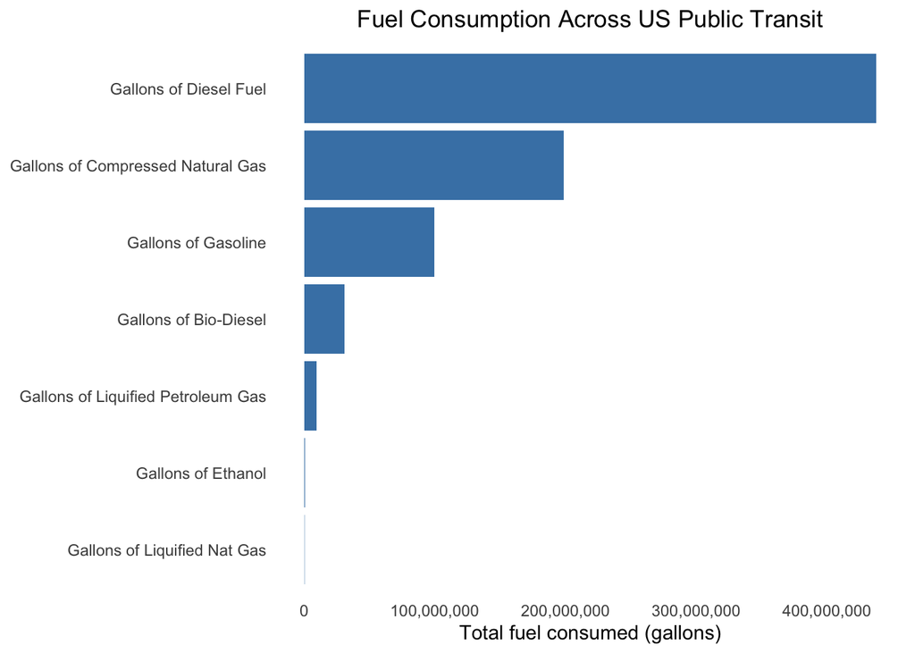

```r
fuel_totals <- NTD_ENERGY |>
  summarise(
    across(all_of(fuel_cols), ~sum(.x, na.rm = TRUE))
  ) |>
  pivot_longer(
    cols = everything(),
    names_to = "Fuel_Type",
    values_to = "Total_Gallons"
  ) |>
  filter(Total_Gallons > 0) |>
  arrange(desc(Total_Gallons))

fuel_totals |>
  ggplot(aes(
    x = reorder(Fuel_Type, Total_Gallons),
    y = Total_Gallons
  )) +
  geom_col(fill = "steelblue") +
  coord_flip() +
  scale_y_continuous(
    labels = scales::label_comma()
  ) +
  labs(
    title = "Fuel Consumption Across US Public Transit",
    x = NULL,
    y = "Total fuel consumed (gallons)"
  ) +
  theme_minimal() +
  theme(
    plot.title = element_text(hjust = 0.5),
    panel.grid = element_blank()
  )
```

#### Least Commonly Used Fuel Source

The least commonly used gallon-measured fuel source was Liquefied natural gas (LNG), with only **1 agency** reporting the usage. Total LNG consumption was approximately 223,362 gallons.

### EDA – NTD Service

#### Average Trip Length on MTA NYC

The average trip length on MTA New York City Transit is approximately **3.18 miles**. It was computed by dividing total passenger miles by total annual unlinked passenger trips (UPT).

#### Five States with the Fewest Passenger Miles

**Top 5 fewest passenger miles code**

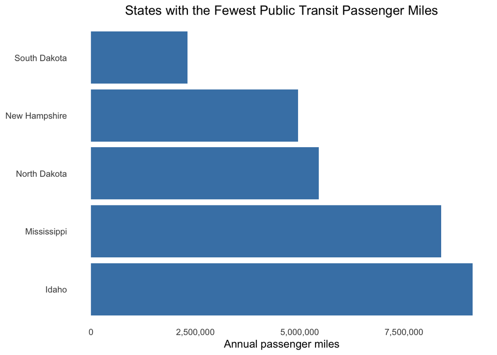

```r
state_passenger_miles <- NTD_SERVICE |>
  filter(state %in% state.abb) |>
  group_by(state) |>
  summarise(
    passenger_miles = if (all(is.na(sum_passenger_miles))) {
      NA_real_
    } else {
      sum(sum_passenger_miles, na.rm = TRUE)
    },
    .groups = "drop"
  ) |>
  mutate(
    state_name = state.name[match(state, state.abb)]
  )

fewest_passenger_miles <- state_passenger_miles |>
  filter(!is.na(passenger_miles)) |>
  slice_min(
    passenger_miles,
    n = 5,
    with_ties = FALSE
  ) |>
  arrange(passenger_miles)

fewest_passenger_miles |>
  ggplot(aes(
    x = reorder(state_name, -passenger_miles),
    y = passenger_miles
  )) +
  geom_col(fill = "steelblue") +
  coord_flip() +
  scale_y_continuous(
    labels = scales::label_comma()
  ) +
  labs(
    title = "States with the Fewest Public Transit Passenger Miles",
    x = NULL,
    y = "Annual passenger miles"
  ) +
  theme_minimal() +
  theme(
    plot.title = element_text(hjust = 0.5),
    panel.grid = element_blank()
  )
```

#### State Coverage in the NTD Service Data

All 50 U.S. states are represented in the NTD Service dataset.

## Data Analysis

#### Calculate Total Emissions

All three datasets were combined in order to calculate annual CO₂ emissions for every agency and transportation mode. To join the datasets, agency identifiers and mode codes were used.

**Joining emissions data code**

```r
service_agency_mode <- NTD_SERVICE |>
  mutate(
    NTD_ID = as.character(as.integer(NTD_ID))
  ) |>
  group_by(NTD_ID, mode) |>
  summarise(
    AGENCY = first(na.omit(AGENCY), default = NA_character_),
    state = first(na.omit(state), default = NA_character_),
    .groups = "drop"
  )

energy_agency_mode <- NTD_ENERGY |>
  mutate(NTD_ID = as.character(as.integer(`NTD ID`))) |>
  group_by(NTD_ID, Mode) |>
  summarise(
    across(
      where(is.numeric),
      ~sum(.x, na.rm = TRUE)
    ),
    .groups = "drop"
  )

emissions_data <- energy_agency_mode |>
  left_join(
    service_agency_mode,
    by = c("NTD_ID", "Mode" = "mode")
  ) |>
  left_join(
    EIA_SEP_REPORT |>
      select(abbreviation, CO2_MWh),
    by = c("state" = "abbreviation")
  )

join_check <- emissions_data |>
  summarise(
    agency_mode_rows = n(),
    missing_states = sum(is.na(state)),
    missing_electricity_factors = sum(is.na(CO2_MWh))
  )
```

The analysis combined direct fuel-combustion CO₂ with indirect CO₂ from electricity generation.

The estimates include biogenic CO₂ from biofuels and exclude hydrogen production emissions. Records without a matching state electricity emissions were assigned missing total emissions and not zero.

**Calculating CO2 emissions code**

```r
kg_to_lb <- 2.20462

agency_emissions <- emissions_data |>
  mutate(

    diesel_co2 =
      `Gallons of Diesel Fuel` * 22.45,

    gasoline_co2 =
      `Gallons of Gasoline` * 20.86,

    kerosene_co2 =
      `Gallons of Kerosene` * 21.78,

    bunker_co2 =
      `Gallons of Bunker Fuel` * 24.78,

    lpg_co2 =
      `Gallons of Liquified Petroleum Gas` * 12.68,

    cng_co2 =
      `Gallons of Compressed Natural Gas` *
      (123.57 / 1000) * 120.85,

    lng_co2 =
      `Gallons of Liquified Nat Gas` *
      4.50 * kg_to_lb,

    biodiesel_co2 =
      `Gallons of Bio-Diesel` *
      9.45 * kg_to_lb,

    ethanol_co2 =
      `Gallons of Ethanol` *
      5.75 * kg_to_lb,

    electricity_kwh =
      `Kilowatt hours of Electric Battery` +
      `Kilowatt hours of Electric Propulsion`,

    electricity_co2 = case_when(
      electricity_kwh == 0 ~ 0,
      is.na(CO2_MWh) ~ NA_real_,
      TRUE ~ (electricity_kwh / 1000) * CO2_MWh
    ),

    fossil_fuel_co2 =
      diesel_co2 + gasoline_co2 +
      kerosene_co2 + bunker_co2 +
      lpg_co2 + cng_co2 + lng_co2,

    biogenic_co2 =
      biodiesel_co2 + ethanol_co2,

    total_co2_lbs =
      fossil_fuel_co2 + biogenic_co2 + electricity_co2,

    total_co2_metric_tons =
      total_co2_lbs / 2204.62
  )

emissions_summary <- agency_emissions |>
  summarise(
    agency_mode_pairs = n(),
    complete_estimates = sum(!is.na(total_co2_lbs)),
    incomplete_estimates = sum(is.na(total_co2_lbs)),
    estimated_co2_metric_tons =
      round(sum(total_co2_metric_tons, na.rm = TRUE))
  )
```

The output accounts for1,130 of 1,134 agency-mode pairs (99.65%), totaling approximately 8.58 million metric tons of CO₂.

The remaining 4 entries were excluded because their electricity consumption could not be linked to state-level factors, meaning that ~ 662.3 million kWh were used in Washington, DC, and Puerto Rico.

**Normalizing emissions code**

```r
agency_co2_totals <- agency_emissions |>
  group_by(NTD_ID) |>
  summarise(
    agency_name = first(na.omit(AGENCY),
                        default = NA_character_),
    total_co2_lbs = if (
      any(is.na(total_co2_lbs))
    ) NA_real_ else sum(total_co2_lbs),
    modes_reported = n(),
    incomplete_modes = sum(is.na(total_co2_lbs)),
    .groups = "drop"
  )

agency_service_totals <- NTD_SERVICE |>
  mutate(NTD_ID = as.character(as.integer(NTD_ID))) |>
  group_by(NTD_ID) |>
  summarise(
    agency_name_service = first(
      na.omit(AGENCY), default = NA_character_
    ),
    total_upt = sum(total_upt, na.rm = TRUE),
    total_passenger_miles = if (
      any(is.na(sum_passenger_miles))
    ) NA_real_ else sum(sum_passenger_miles),
    .groups = "drop"
  )

agency_efficiency <- agency_co2_totals |>
  left_join(agency_service_totals, by = "NTD_ID") |>
  mutate(
    agency_name = coalesce(agency_name, agency_name_service),

co2_per_upt = if_else(
  total_upt > 0 & incomplete_modes == 0,
  total_co2_lbs / total_upt,
  NA_real_
),
co2_per_passenger_mile = if_else(
  total_passenger_miles > 0 & incomplete_modes == 0,
  total_co2_lbs / total_passenger_miles,
  NA_real_
)

  )
```

#### Emissions Efficiency by Agency Size

To compute total emissions per UPT and per passenger mile, agencies were broken into small (fewer than 1 million annual trips), medium (1 million to 10 million), and large (10 million or more) bins. Additionally, agencies with fewer than 100 000 annual trips and/or incomplete emissions were excluded.

**Ranking transit agencies code**

```r
agency_rankings <- agency_efficiency |>
  mutate(
    agency_size = case_when(
      total_upt < 1e6 ~ "Small",
      total_upt < 1e7 ~ "Medium",
      TRUE ~ "Large"
    ),
    agency_size = factor(
      agency_size,
      levels = c("Small", "Medium", "Large")
    )
  ) |>
  filter(
    incomplete_modes == 0,
    total_upt >= 100000
  )

shorten_agency_name <- function(x) {
  dplyr::case_when(
    grepl("Milwaukee Streetcar", x) ~ "Milwaukee Streetcar (The Hop)",
    grepl("McKinney Avenue", x) ~ "McKinney Avenue Transit",
    grepl("Chicago Water Taxi", x) ~ "Chicago Water Taxi",
    grepl("Seattle Center Monorail", x) ~ "Seattle Center Monorail",
    grepl("Anaheim", x) ~ "Anaheim Regional Transportation",
    grepl("Portland Streetcar", x) ~ "Portland Streetcar",
    grepl("TriMet", x) ~ "TriMet",
    grepl("MTA New York City Transit", x) ~ "MTA NYC Transit",
    grepl("San Francisco Municipal", x) ~ "SFMTA",
    grepl("Adirondack", x) ~ "Adirondack Trailways",
    grepl("Hampton Jitney", x) ~ "Hampton Jitney",
    grepl("SANDAG", x) ~ "SANDAG",
    grepl("CalVans", x) ~ "CalVans",
    grepl("SF BART", x) ~ "BART",
    grepl("Trans-Hudson", x) ~ "PATH",
    TRUE ~ x
  )
}

best_per_upt <- agency_rankings |>
  filter(!is.na(co2_per_upt)) |>
  group_by(agency_size) |>
  slice_min(co2_per_upt, n = 3, with_ties = FALSE) |>
  ungroup() |>
  select(
    agency_size,
    agency_name,
    total_upt,
    co2_per_upt
  ) |>
  mutate(
    total_upt = round(total_upt),
    co2_per_upt = round(co2_per_upt, 3)
  )

knitr::kable(
  best_per_upt |>
    mutate(agency_name = shorten_agency_name(agency_name)),
  caption = "Most Efficient Agencies by CO₂ per Passenger Trip",
  col.names = c(
    "Agency Size", "Transit Agency",
    "Annual UPT", "Pounds CO2 per UPT"
  ),
  format.args = list(big.mark = ",")
)
```

Most Efficient Agencies by CO₂ per Passenger Trip

| Agency Size | Transit Agency | Annual UPT | Pounds CO2 per UPT |
| --- | --- | --- | --- |
| Small | Milwaukee Streetcar (The Hop) | 494,557 | 0.317 |
| Small | McKinney Avenue Transit | 305,271 | 0.731 |
| Small | Chicago Water Taxi | 538,075 | 0.943 |
| Medium | Seattle Center Monorail | 2,292,743 | 0.058 |
| Medium | Anaheim Regional Transportation | 8,284,155 | 0.206 |
| Medium | Portland Streetcar | 4,111,090 | 0.246 |
| Large | TriMet | 65,782,710 | 0.412 |
| Large | MTA NYC Transit | 3,014,773,373 | 0.585 |
| Large | SFMTA | 168,353,193 | 0.808 |

**Ranking transit agencies code**

```r
best_per_mile <- agency_rankings |>
  filter(!is.na(co2_per_passenger_mile)) |>
  group_by(agency_size) |>
  slice_min(
    co2_per_passenger_mile,
    n = 3,
    with_ties = FALSE
  ) |>
  ungroup() |>
  select(
    agency_size,
    agency_name,
    total_passenger_miles,
    co2_per_passenger_mile
  ) |>
  mutate(
    total_passenger_miles = round(total_passenger_miles),
    co2_per_passenger_mile =
      round(co2_per_passenger_mile, 3)
  )

knitr::kable(
  best_per_mile |>
    mutate(agency_name = shorten_agency_name(agency_name)),
  caption = "Most Efficient Agencies by CO₂ per Passenger Mile",
  col.names = c(
    "Agency Size", "Transit Agency",
    "Annual Passenger Miles",
    "Pounds CO2 per Passenger Mile"
  ),
  format.args = list(big.mark = ",")
)
```

Most Efficient Agencies by CO₂ per Passenger Mile

| Agency Size | Transit Agency | Annual Passenger Miles | Pounds CO2 per Passenger Mile |
| --- | --- | --- | --- |
| Small | Adirondack Trailways | 31,332,336 | 0.146 |
| Small | Hampton Jitney | 59,566,698 | 0.169 |
| Small | SANDAG | 47,811,777 | 0.180 |
| Medium | Seattle Center Monorail | 2,063,469 | 0.064 |
| Medium | Anaheim Regional Transportation | 11,789,535 | 0.145 |
| Medium | CalVans | 99,336,553 | 0.155 |
| Large | TriMet | 270,786,952 | 0.100 |
| Large | BART | 804,179,562 | 0.151 |
| Large | PATH | 298,848,234 | 0.180 |

#### GTA IV - Green Transit Awards Preparation

The awards chosen for this projects are Greenest Transit Agency and The Dirtiest of the Dirtiest.

##### Greenest Transit Agency

This award only includes large transit agencies (at least 10 million annual UPT’s ) with the lowest estimated CO₂ emissions per passenger mile.

**Greenest Transit Agency award code**

```r
greenest_candidates <- agency_rankings |>
  filter(
    agency_size == "Large",
    !is.na(co2_per_passenger_mile),
    co2_per_passenger_mile > 0,
    !is.na(co2_per_upt),
    co2_per_upt > 0
  ) |>
  arrange(co2_per_passenger_mile)

greenest_winner <- greenest_candidates |>
  slice_head(n = 1)

greenest_candidates |>
  slice_head(n = 3) |>
  mutate(
    Placement = c(
      "Winner",
      "1st Runner-Up",
      "2nd Runner-Up"
    )
  ) |>
  transmute(
    Placement,
    Agency = case_when(
  grepl("TriMet", agency_name) ~ "TriMet",
  grepl("BART", agency_name) ~ "BART",
  grepl("Trans-Hudson", agency_name) ~ "PATH",
  TRUE ~ agency_name
),
    `Annual UPT` = total_upt,
    `CO2 per Passenger Mile` =
      round(co2_per_passenger_mile, 3),
    `CO2 per UPT` = round(co2_per_upt, 3)
  ) |>
  knitr::kable(
    format.args = list(big.mark = ",")
  )
```

| Placement | Agency | Annual UPT | CO2 per Passenger Mile | CO2 per UPT |
| --- | --- | --- | --- | --- |
| Winner | TriMet | 65,782,710 | 0.100 | 0.412 |
| 1st Runner-Up | BART | 58,368,709 | 0.151 | 2.083 |
| 2nd Runner-Up | PATH | 64,279,458 | 0.180 | 0.835 |

##### The Dirtiest of the Dirtiest

The award identifies the least emissions-efficient transit agency operating in a “coal” state, where electricity accounts for at least 40% of estimated operational CO₂ emissions. Additionally, the agencies should have served at least 1 million annual passenger trips.

**Show R code for the Dirtiest of the Dirtiest award**

```r
dirtiest_candidates <- coal_agency_emissions |>
  filter(
    state %in% coal_states,
    total_upt >= 1e6,
    incomplete_modes == 0,
    !is.na(co2_per_passenger_mile),
    co2_per_passenger_mile > 0,
    electricity_emissions_share >= 0.40
  ) |>
  arrange(desc(co2_per_passenger_mile))

dirtiest_winner <- dirtiest_candidates |>
  slice_head(n = 1)

dirtiest_candidates |>
  slice_head(n = 3) |>
  mutate(
    Placement = c(
      "Winner",
      "2nd",
      "3rd"
    )
  ) |>
  transmute(
    Placement,
    Agency = case_when(
  grepl("Personal Rapid Transit", agency_name) ~ "WVU Personal Rapid Transit",
  grepl("Kansas City Streetcar", agency_name) ~ "Kansas City Streetcar",
  grepl("South Shore Line", agency_name) ~ "South Shore Line",
  TRUE ~ agency_name
),
    State = state,
    `Annual UPT` = total_upt,
    `Electricity Share (%)` =
      round(electricity_emissions_share * 100, 1),
    `CO2 per Passenger Mile` =
      round(co2_per_passenger_mile, 3)
  ) |>
  knitr::kable(
    format.args = list(big.mark = ",")
  )
```

| Placement | Agency | State | Annual UPT | Electricity Share (%) | CO2 per Passenger Mile |
| --- | --- | --- | --- | --- | --- |
| Winner | WVU Personal Rapid Transit | WV | 1,453,453 | 100 | 1.782 |
| 2nd | Kansas City Streetcar | MO | 1,646,825 | 100 | 1.185 |
| 3rd | South Shore Line | IN | 2,030,155 | 100 | 0.456 |

#### Extra Credit Investigation: The Electric Paradox

Is it possible that an electric transit system can still have a substantial carbon footprint? The electricity consumption and state electricity emissions factors were compared to answer this question.

**Electric Paradox investigation code**

```r
library(dplyr)

electric_paradox_data <- agency_emissions |>
  filter(NTD_ID %in% dirtiest_candidates$NTD_ID) |>
  group_by(NTD_ID) |>
  summarise(
    electricity_kwh = sum(electricity_kwh, na.rm = TRUE),
    electricity_co2_lbs = sum(electricity_co2, na.rm = TRUE),
    .groups = "drop"
  ) |>
  left_join(
    agency_efficiency |>
      select(
        NTD_ID,
        agency_name,
        total_passenger_miles,
        co2_per_passenger_mile
      ),
    by = "NTD_ID"
  ) |>
  left_join(
    dirtiest_candidates |>
      select(NTD_ID, state),
    by = "NTD_ID"
  ) |>
  left_join(
    EIA_SEP_REPORT |>
      select(abbreviation, CO2_MWh, primary_source),
    by = c("state" = "abbreviation")
  ) |>
  mutate(
    kwh_per_passenger_mile =
      electricity_kwh / total_passenger_miles,
    grid_co2_per_kwh = CO2_MWh / 1000,
    estimated_electric_co2_per_mile =
      kwh_per_passenger_mile * grid_co2_per_kwh
  ) |>
  arrange(desc(co2_per_passenger_mile))

electric_paradox_data |>
  transmute(
    Agency = case_when(
  grepl("Personal Rapid Transit", agency_name) ~ "WVU Personal Rapid Transit",
  grepl("Kansas City Streetcar", agency_name) ~ "Kansas City Streetcar",
  grepl("South Shore Line", agency_name) ~ "South Shore Line",
  TRUE ~ agency_name
),
    State = state,
    `Electricity per Passenger Mile (kWh)` =
      round(kwh_per_passenger_mile, 3),
    `Grid CO2 per kWh (lb)` =
      round(grid_co2_per_kwh, 3),
    `Estimated CO2 per Passenger Mile (lb)` =
      round(estimated_electric_co2_per_mile, 3)
  ) |>
  knitr::kable(
    format.args = list(big.mark = ",")
  )
```

| Agency | State | Electricity per Passenger Mile (kWh) | Grid CO2 per kWh (lb) | Estimated CO2 per Passenger Mile (lb) |
| --- | --- | --- | --- | --- |
| WVU Personal Rapid Transit | WV | 0.932 | 1.912 | 1.782 |
| Kansas City Streetcar | MO | 0.814 | 1.456 | 1.185 |
| South Shore Line | IN | 0.328 | 1.393 | 0.456 |

#### GTA IV Green Transit Awards Press Release

## The Good, the Bad, and the Carbon: GTA IV Green Transit Awards

The GTA IV Green Transit Award Committee celebrates U.S. public transportation agencies for their effort to reduce the carbon dioxide (CO₂) footprint in the country. This year, the Committee presented two completely opposite awards - **Greenest Transit Agency**, recognizing exceptional emissions efficiency among major transit systems, and **The Dirtiest of the Dirtiest**, highlighting high estimated emissions intensity among electricity-dependent transit agencies operating in coal-primary states. To determine the winners, the GTA IV used energy consumption and passenger service data from the National Transit Database (NTD) and state-level electricity emissions reports from the U.S. Energy Information Administration (EIA).

### 🏆 Award: Greenest Transit Agency

**Winner:** TriMet (Portland, Oregon)

**Estimated emissions:** 0.100 pounds of CO₂ per passenger mile

TriMet earns the Greenest Transit Agency Award for achieving the lowest estimated CO₂ emissions per passenger mile outperforming **72** eligible major transit agencies.

The GTA IV Foundation evaluated agencies with at least 10 million annual unlinked passenger trips and passenger-mile estimates. The analysis conducted defined emissions intensity by dividing estimated annual operational CO₂ emissions, including electricity-generation emissions, by total annual passenger miles.

TriMet’s estimated emissions intensity is **87.1% lower** than the eligible-agency median of **0.776** pounds of CO₂ per passenger mile.

The runners-up are **BART (San Francisco, California)** and **PATH (New York City, New York)**.

*TriMet proves that when it comes to carbon emissions, going the extra mile doesn’t have to cost the Earth.*

**Greenest Transit Agency visualization code**

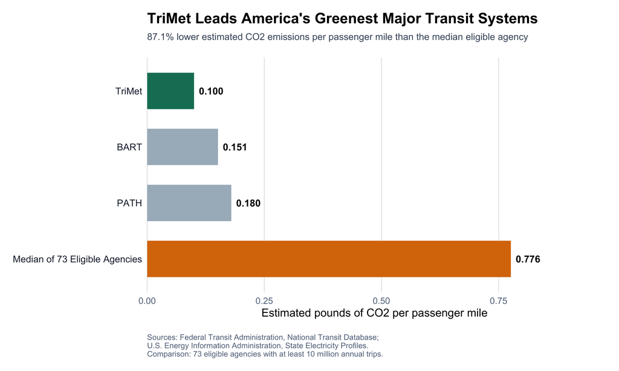

```r
library(ggplot2)
library(dplyr)

greenest_median <- median(
  greenest_candidates$co2_per_passenger_mile,
  na.rm = TRUE
)

greenest_plot_data <- greenest_candidates |>
  slice_head(n = 3) |>
  mutate(
    Agency = case_when(
      grepl("TriMet", agency_name, ignore.case = TRUE) ~ "TriMet",
      grepl("Bay Area Rapid Transit", agency_name,
            ignore.case = TRUE) ~ "BART",
      grepl("Trans-Hudson", agency_name,
            ignore.case = TRUE) ~ "PATH",
      grepl("New York City Transit", agency_name,
            ignore.case = TRUE) ~ "MTA New York City Transit",
      grepl("Long Island Rail Road", agency_name,
            ignore.case = TRUE) ~ "MTA Long Island Rail Road",
      TRUE ~ agency_name
    ),
    Category = if_else(
      row_number() == 1,
      "Award Winner",
      "Other Top Agencies"
    )
  ) |>
  select(Agency, co2_per_passenger_mile, Category)

greenest_plot_data <- bind_rows(
  greenest_plot_data,
  tibble(
    Agency = "Median of 73 Eligible Agencies",
    co2_per_passenger_mile = greenest_median,
    Category = "Eligible Agency Median"
  )
) |>
  mutate(
    Agency = factor(
      Agency,
      levels = rev(Agency)
    )
  )

ggplot(
  greenest_plot_data,
  aes(
    x = co2_per_passenger_mile,
    y = Agency,
    fill = Category
  )
) +
  geom_col(width = 0.65) +
  geom_text(
    aes(label = sprintf("%.3f", co2_per_passenger_mile)),
    hjust = -0.2,
    size = 4,
    fontface = "bold"
  ) +
  scale_fill_manual(
    values = c(
      "Award Winner" = "#147D64",
      "Other Top Agencies" = "#A8B8C5",
      "Eligible Agency Median" = "#D97706"
    )
  ) +
  scale_x_continuous(
    limits = c(0, greenest_median * 1.25),
    expand = expansion(mult = c(0, 0))
  ) +
  labs(
    title = "TriMet Leads America's Greenest Major Transit Systems",
    subtitle = paste0(
      "87.1% lower estimated CO2 emissions per passenger mile ",
      "than the median eligible agency"
    ),
    x = "Estimated pounds of CO2 per passenger mile",
    y = NULL,
    caption = paste0(
  "Sources: Federal Transit Administration, National Transit Database;\n",
  "U.S. Energy Information Administration, State Electricity Profiles.\n",
  "Comparison: 73 eligible agencies with at least 10 million annual trips."
)
  ) +
  coord_cartesian(clip = "off") +
  theme_minimal(base_size = 13) +
  theme(
    plot.title = element_text(
      face = "bold",
      size = 17,
      margin = margin(b = 8)
    ),
    plot.subtitle = element_text(
      size = 11,
      color = "#475569",
      margin = margin(b = 18)
    ),
    axis.text.y = element_text(
      size = 11,
      color = "#1E293B"
    ),
    axis.text.x = element_text(color = "#64748B"),
    panel.grid.major.y = element_blank(),
    panel.grid.minor = element_blank(),
    legend.position = "none",
    plot.caption = element_text(
      size = 9,
      color = "#64748B",
      hjust = 0,
      linehight = 1.2,
      margin = margin(t = 18)
    ),
    plot.margin = margin(15, 20, 15, 15)
  )
```

### 🏭 Anti-Award: The Dirtiest of the Dirtiest

*The Coal-Grid Carbon Intensity Anti-Award*

**Winner:** WVU Personal Rapid Transit (Morgantown, West Virginia)

**Estimated emissions:** 1.782 pounds of CO₂ per passenger mile

West Virginia University’s Personal Rapid Transit system receives the Dirtiest of the Dirtiest Anti-Award for recording the highest estimated CO₂ emissions per passenger mile among qualifying transit agencies operating in coal-primary electricity states.

The eligible agencies serve at least 1 million annual passenger trips, have complete emissions and passenger-mile data, and derive at least 40% of their estimated operational CO₂ emissions from electricity generation.

WVU’s estimated emissions intensity is **50.3% higher** than the median of 3 qualifying agencies, where the median is **1.185** pounds of CO₂ per passenger mile.

The runners-up are **Kansas City Streetcar (Kansas City, Missouri)** and **South Shore Line (Northwest Indiana)**.

*WVU Personal Rapid Transit may run on electricity, but its estimated carbon footprint is anything but light. Sometimes, the dirtiest part of the ride happens before the train even leaves the station.*

**Dirtiest of the Dirtiest visualization code**

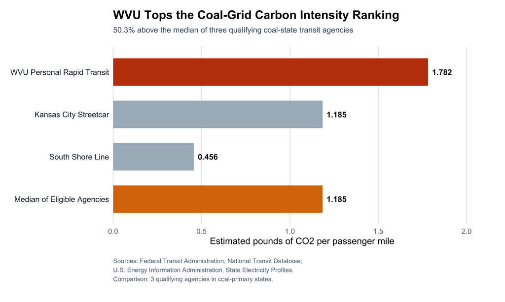

```r
library(ggplot2)
library(dplyr)

dirtiest_median <- median(
  dirtiest_candidates$co2_per_passenger_mile,
  na.rm = TRUE
)

dirtiest_difference <- 100 * (
  dirtiest_winner$co2_per_passenger_mile[1] /
    dirtiest_median - 1
)

dirtiest_plot_data <- dirtiest_candidates |>
  slice_head(n = 3) |>
  mutate(
    Agency = case_when(
      grepl("Personal Rapid Transit", agency_name,
            ignore.case = TRUE) ~ "WVU Personal Rapid Transit",
      grepl("Kansas City Streetcar", agency_name,
            ignore.case = TRUE) ~ "Kansas City Streetcar",
      grepl("South Shore Line", agency_name,
            ignore.case = TRUE) ~ "South Shore Line",
      TRUE ~ agency_name
    ),
    Category = if_else(
      row_number() == 1,
      "Award Winner",
      "Other Finalists"
    )
  ) |>
  select(Agency, co2_per_passenger_mile, Category)

dirtiest_plot_data <- bind_rows(
  dirtiest_plot_data,
  tibble::tibble(
    Agency = "Median of Eligible Agencies",
    co2_per_passenger_mile = dirtiest_median,
    Category = "Eligible Agency Median"
  )
) |>
  mutate(
    Agency = factor(
      Agency,
      levels = rev(Agency)
    )
  )

ggplot(
  dirtiest_plot_data,
  aes(
    x = co2_per_passenger_mile,
    y = Agency,
    fill = Category
  )
) +
  geom_col(width = 0.65) +
  geom_text(
    aes(label = sprintf("%.3f", co2_per_passenger_mile)),
    hjust = -0.2,
    size = 4,
    fontface = "bold"
  ) +
  scale_fill_manual(
    values = c(
      "Award Winner" = "#C2410C",
      "Other Finalists" = "#A8B8C5",
      "Eligible Agency Median" = "#D97706"
    )
  ) +
  scale_x_continuous(
    limits = c(
      0,
      max(dirtiest_plot_data$co2_per_passenger_mile) * 1.20
    ),
    breaks = seq(0, 2, by = 0.5),
    expand = expansion(mult = c(0, 0))
  ) +
  labs(
    title = "WVU Tops the Coal-Grid Carbon Intensity Ranking",
    subtitle = paste0(
  sprintf("%.1f", dirtiest_difference),
  "% above the median of three qualifying coal-state transit agencies"
),
    x = "Estimated pounds of CO2 per passenger mile",
    y = NULL,
    caption = paste0(
  "Sources: Federal Transit Administration, National Transit Database;\n",
  "U.S. Energy Information Administration, State Electricity Profiles.\n",
  "Comparison: 3 qualifying agencies in coal-primary states.\n"
)
  ) +
  coord_cartesian(clip = "off") +
  theme_minimal(base_size = 13) +
  theme(
    plot.title = element_text(
      face = "bold",
      size = 17,
      margin = margin(b = 8)
    ),
    plot.subtitle = element_text(
      size = 11,
      color = "#475569",
      margin = margin(b = 18)
    ),
    axis.text.y = element_text(
      size = 11,
      color = "#1E293B"
    ),
    axis.text.x = element_text(
      color = "#64748B"
    ),
    panel.grid.major.y = element_blank(),
    panel.grid.minor = element_blank(),
    legend.position = "none",
    plot.caption = element_text(
      size = 9,
      color = "#64748B",
      hjust = 0,
      lineheight = 1.2,
      margin = margin(t = 18)
    ),
    plot.margin = margin(15, 20, 15, 15)
  )
```

#### The Electric Paradox: When Clean Technology Meets a Dirty Grid

Electric transit may eliminate tailpipe emissions, but it does not eliminate the carbon footprint of electricity generation. The analysis exposes that the winner of the *Dirtiest of the Dirtiest Anti-Award* faces a double challenge - high electricity consumption per passenger mile and a carbon-intensive state electricity grid.

WVU Personal Rapid Transit consumes approximately **2.84 times more** electricity per passenger mile than South Shore Line, while West Virginia’s electricity emissions factor is **37.3% higher** than Indiana’s. Combined, these factors result in approximately **3.90 times** as much CO₂ per passenger mile for WVU.

**An electric ride can still carry a heavy carbon footprint when energy consumption and grid emissions intensity work against each other.** These comparisons use statewide average emissions factors rather than agency-specific electricity purchases.

**NoteAI Usage Statement**

ChatGPT was used to help write, analyze and improve code in this project, but all non-code text was written without the use of any Generative AI tools. Additionally, ChatGPT was used to check grammar, punctuation, collocations used, and spelling.